# Lab 3

Jeffrey Stevenson

2021-02-12

# Tasks

## Task 1

```r
getwd()
```

```
## [1] "C:/Users/jeffr/OneDrive/Desktop/School/Spring 2021/Statistics/MATH4753stev0009/Labs/LAB3"
```

## Task 2

```r
spruce.df = read.csv("SPRUCE.csv")
head(spruce.df)
```

```
##   BHDiameter Height
## 1       18.9   20.0
## 2       16.6   18.8
## 3       15.5   16.8
## 4       15.5   16.9
## 5       19.4   20.2
## 6       13.7   16.3
```

## Task 3

**Tree Height vs BHDiameter Plot**

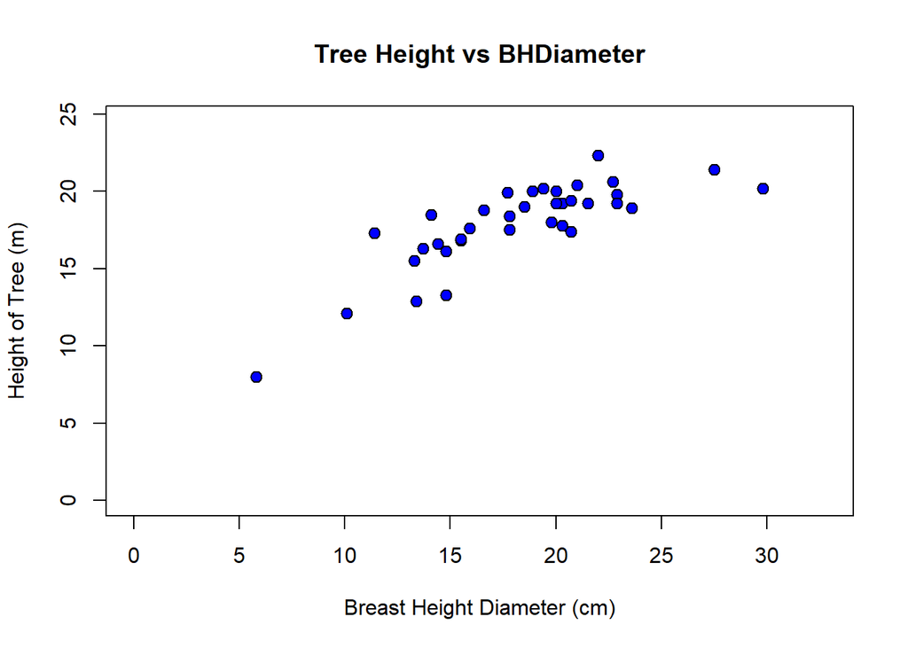

```r
plot(Height~BHDiameter, main = "Tree Height vs BHDiameter", xlab = "Breast Height Diameter (cm)", ylab = "Height of Tree (m)", pch = 21, bg = "blue", cex = 1.2, xlim = c(0,max(BHDiameter) *1.1), ylim = c(0, max(Height) * 1.1), data = spruce.df)
```

Based on graph, there appears to be partial straight line relationship.

```r
library(s20x)

lo = layout(matrix(1:3, nr = 3, nc = 1, byrow = TRUE))
tsone = trendscatter(Height~BHDiameter, f = 0.5, data = spruce.df)
tstwo = trendscatter(Height~BHDiameter, f = 0.6, data = spruce.df)
tsthree = trendscatter(Height~BHDiameter, f = 0.7, data = spruce.df)
```

[figure not shown]

```r
spruce.lm = with(spruce.df, lm(Height~BHDiameter)) #lm=linear model, y~x
summary(spruce.lm) #9.15 = beta0hat, 0.48 = beta1hat
```

```
##
## Call:
## lm(formula = Height ~ BHDiameter)
##
## Residuals:
##     Min      1Q  Median      3Q     Max
## -3.9394 -0.9763  0.2829  0.9950  2.6644
##
## Coefficients:
##             Estimate Std. Error t value Pr(>|t|)
## (Intercept)  9.14684    1.12131   8.157 1.63e-09 ***
## BHDiameter   0.48147    0.05967   8.069 2.09e-09 ***
## ---
## Signif. codes:  0 '***' 0.001 '**' 0.01 '*' 0.05 '.' 0.1 ' ' 1
##
## Residual standard error: 1.678 on 34 degrees of freedom
## Multiple R-squared:  0.6569, Adjusted R-squared:  0.6468
## F-statistic:  65.1 on 1 and 34 DF,  p-value: 2.089e-09
```

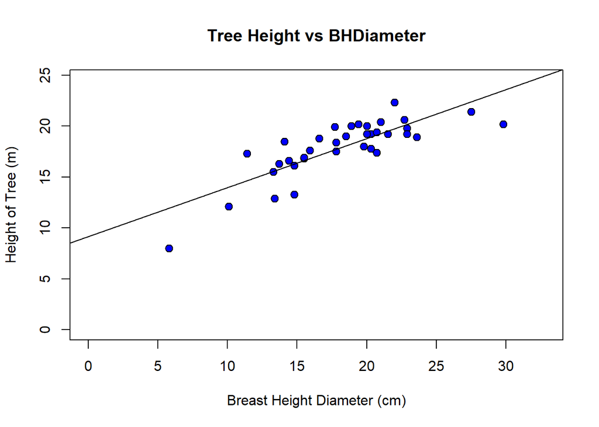

```r
plot(Height~BHDiameter, main = "Tree Height vs BHDiameter", xlab = "Breast Height Diameter (cm)", ylab = "Height of Tree (m)", pch = 21, bg = "blue", cex = 1.2, xlim = c(0,max(BHDiameter) *1.1), ylim = c(0, max(Height) * 1.1), data = spruce.df)
abline(spruce.lm)
```

I believe the straight line is appropriate for the plot, but the smoother curve fits the data slightly better. This is because the data has some what of a curved trend to it, but with the limited amount of data we have, the straight line (linear model) fits it somewhat well.

## Task 4

**4-Square Plot**

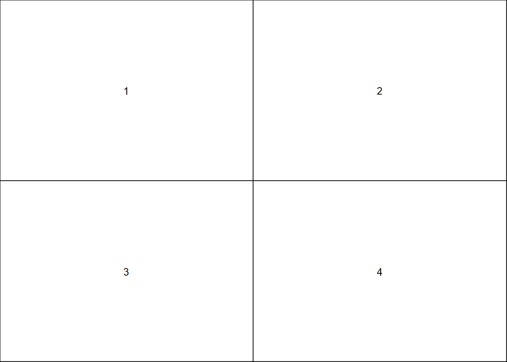

```r
lo = layout(matrix(1:4, nr = 2, nc = 2, byrow = TRUE))
layout.show(4)
```

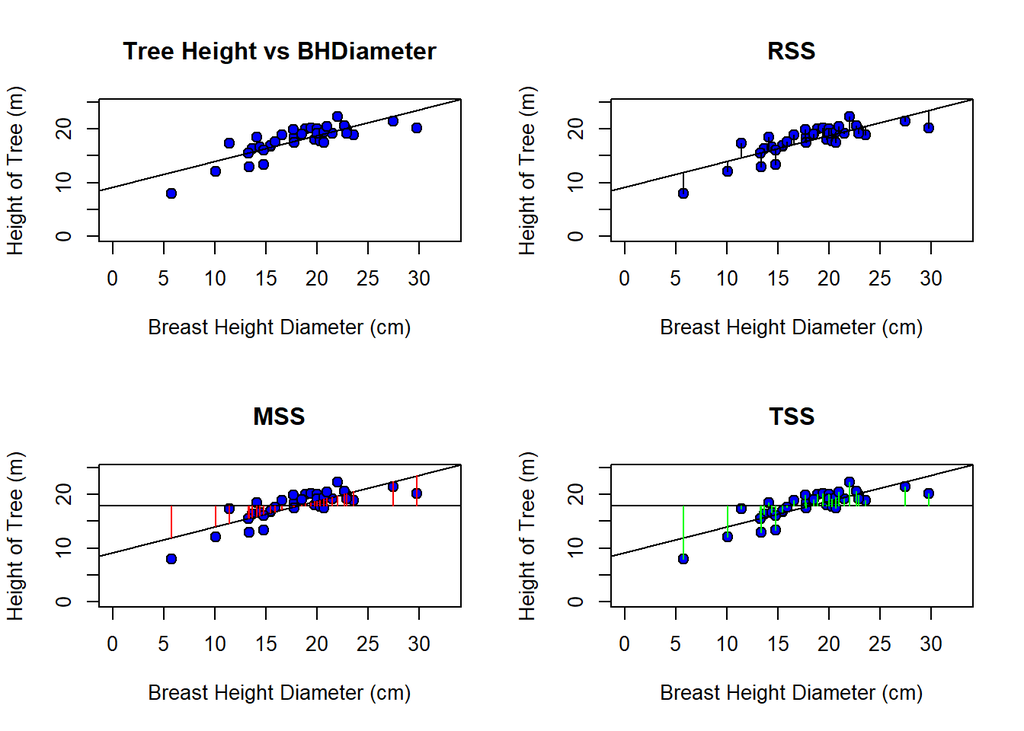

```r
plot(Height~BHDiameter, main = "Tree Height vs BHDiameter", xlab = "Breast Height Diameter (cm)", ylab = "Height of Tree (m)", pch = 21, bg = "blue", cex = 1.2, xlim = c(0,max(BHDiameter) *1.1), ylim = c(0, max(Height) * 1.1), data = spruce.df)
abline(spruce.lm)

plot(Height~BHDiameter, main = "RSS", xlab = "Breast Height Diameter (cm)", ylab = "Height of Tree (m)", pch = 21, bg = "blue", cex = 1.2, xlim = c(0,max(BHDiameter) *1.1), ylim = c(0, max(Height) * 1.1), data = spruce.df)
abline(spruce.lm)
yHat=with(spruce.df,predict(spruce.lm, data.frame(BHDiameter)))
with(spruce.df, segments(BHDiameter, Height, BHDiameter, yHat))

plot(Height~BHDiameter, main = "MSS", xlab = "Breast Height Diameter (cm)", ylab = "Height of Tree (m)", pch = 21, bg = "blue", cex = 1.2, xlim = c(0,max(BHDiameter) *1.1), ylim = c(0, max(Height) * 1.1), data = spruce.df)
abline(spruce.lm)
with(spruce.df, abline(h=mean(Height)))
with(spruce.df, segments(BHDiameter,mean(Height),BHDiameter,yHat,col="Red"))

plot(Height~BHDiameter, main = "TSS", xlab = "Breast Height Diameter (cm)", ylab = "Height of Tree (m)", pch = 21, bg = "blue", cex = 1.2, xlim = c(0,max(BHDiameter) *1.1), ylim = c(0, max(Height) * 1.1), data = spruce.df)
abline(spruce.lm)
with(spruce.df, abline(h=mean(Height)))
with(spruce.df, segments(BHDiameter,Height,BHDiameter,mean(Height),col="Green"))
```

**Calculate TSS, MSS, and RSS**

```r
RSS=with(spruce.df,sum((Height-yHat)^2))
MSS=with(spruce.df,sum((yHat-mean(Height))^2))
TSS=with(spruce.df,sum((mean(Height)-Height)^2))
RSS
```

```
## [1] 95.70281
```

```r
MSS
```

```
## [1] 183.2447
```

```r
TSS
```

```
## [1] 278.9475
```

**Calculate MSS/TSS and interpret it**

```r
MSS/TSS
```

```
## [1] 0.6569146
```

MSS/TSS, otherwise known as R^2, shows how reliably the linear model fits the data. The calculated value of 0.657 shows that the linear model doesn’t fit very well.

**Does TSS=MSS+RSS?**

```r
TSS
```

```
## [1] 278.9475
```

```r
MSS+RSS
```

```
## [1] 278.9475
```

Yes,TSS=MSS+RSS.

**Summarize spruce.lm**

```r
summary(spruce.lm)
```

```
##
## Call:
## lm(formula = Height ~ BHDiameter)
##
## Residuals:
##     Min      1Q  Median      3Q     Max
## -3.9394 -0.9763  0.2829  0.9950  2.6644
##
## Coefficients:
##             Estimate Std. Error t value Pr(>|t|)
## (Intercept)  9.14684    1.12131   8.157 1.63e-09 ***
## BHDiameter   0.48147    0.05967   8.069 2.09e-09 ***
## ---
## Signif. codes:  0 '***' 0.001 '**' 0.01 '*' 0.05 '.' 0.1 ' ' 1
##
## Residual standard error: 1.678 on 34 degrees of freedom
## Multiple R-squared:  0.6569, Adjusted R-squared:  0.6468
## F-statistic:  65.1 on 1 and 34 DF,  p-value: 2.089e-09
```

**Value of slope and intercept? Equation of fitted line?**

Slope = 0.48147 Intercept = 9.14684 Equation: Height = (BHDiameter * 0.48147) + 9.14684

**Predict height of spruce when diameter is 15, 18, and 20cm**

```r
predict(spruce.lm, data.frame(BHDiameter=c(15,18,20)))
```

```
##        1        2        3
## 16.36895 17.81338 18.77632
```

15cm: 16.36895 18cm: 17.81338 20cm: 18.77632

## Task 6

**Height vs. Diameter Plot**

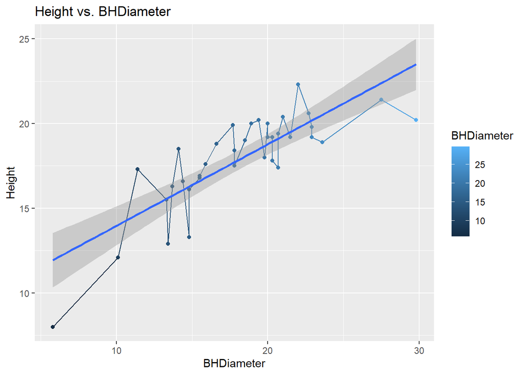

```r
library(ggplot2)
g=ggplot(spruce.df, aes(x=BHDiameter,y=Height,colour=BHDiameter))
g=g+geom_point() + geom_line()+ geom_smooth(method="lm")
g+ggtitle("Height vs. BHDiameter",)
```

## Task 7

[figure not shown]

[figure not shown]

[figure not shown]